# Kishida Lab HPC Documentation (Version 1.0)

Sanjeev Namjoshi

August 2018

# 1. Introduction to the high performance computing (HPC) cluster (HPCC)

A computer designed for HPC is similar to a normal desktop or laptop computer but contains considerably more processing power. The smallest unit of the HPC cluster is a *core*. Typically, 2-32 of these cores will make up a *processor* (also called a central processing unit or *CPU*). Many of these processors are arranged together into a *node*. Finally, these nodes are part of an *enclosure* of which there 3 for the compute nodes as Wake Forest Medical. There are 16 compute nodes per enclosure for our system bringing the grand total to 48 nodes. Collectively, the entire systems is referred to as a *cluster*.

In the HPC cluster environment, all of these units communicate and distribute data processing according to user instructions. The advantage of computing in this way is two-fold. First, there is access to far more computing resources for a particular task. Second, if set up properly by the user, it is possible to distribute the data processing among multiple nodes simultaneously to process the data in parallel.

An overview of the hierarchy is shown in the diagram below:

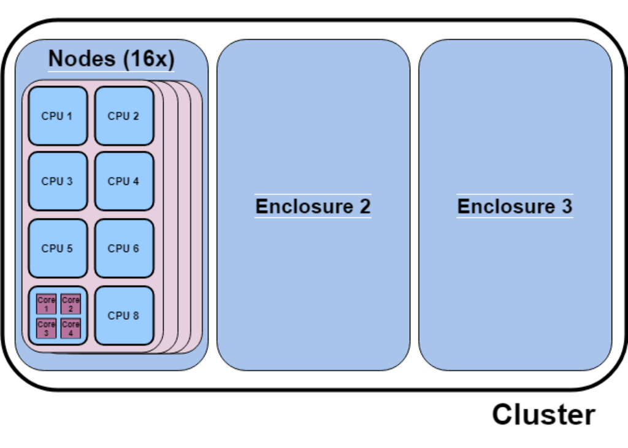

There are different types of nodes available in most computing environments. *Login/head nodes* are nodes that are accessed directly by the user in order to communicate with the computing cluster. No computation should be performed on these nodes. The login nodes sends information to two sources. The first is the *compute nodes* where the actual computation takes place. The second is the *GPU nodes* for graphics processing unit (GPU) computing. Since GPU’s are typically designed with parallel processing in mind, they can be extremely fast for computation. This guide does not consider GPU computing since it is likely to be overkill for our typical analyses. However, it is possible to send GPU jobs simply by modifying the instructions you send to the HPCC.

# 2. Overview of Wake Forest Medical HPC cluster

## 2.1 Futher details

All nodes are run on the Linux operating system Red Hat 6.4. Any batch processes sent to the cluster are run through SLURM 2.3.4 (see **section 4**). The storage paths for the login nodes are `$HOME` and `$SHARE`. These storage areas are supported by isilon-hpc network file systems.

*Internode communication (MPI)*: Set up through an FDR Mellanox InfiniBand network

*Head nodes*: There are 2 administrative nodes that manage the other nodes in the cluster. One of the nodes, the Bright Cluster Manager is responsible for allocating necessary computing resources for updates/patching, monitoring, and general HPC administration. The other node, the SLURM Workload Manager, provides job queuing, submitting, monitoring, accounting, resource load balancing, and other logistics.

*Login (test) nodes*: There are two user login nodes that allow the user to interface with the HPC. Applications on these nodes are equivalent to runtime nodes available on the compute nodes. The development environment here can be used to optimize and test code to verify it runs properly on the compute nodes.

*Compute nodes*: There are 48 compute nodes, a 16 Dell M620 nodes enclosed within one of three total Dell M1000e enclosures (16 nodes/enclosure). Each node has two Intel E5-2670 32-core Sandy Bridge EP processors with 128GB DDR3 memory.

*GPU computing*: 2 nodes total. They consist of Intel CPU E5-2670 32-cores (Sandy Bridge EP) with 128GB DDR3 memory and two NVIDIA K20m GPU 2496-cuda-core (Tesla) accelerators with 5GB GDDR5 memory per GPU.

The entire system is shown below:

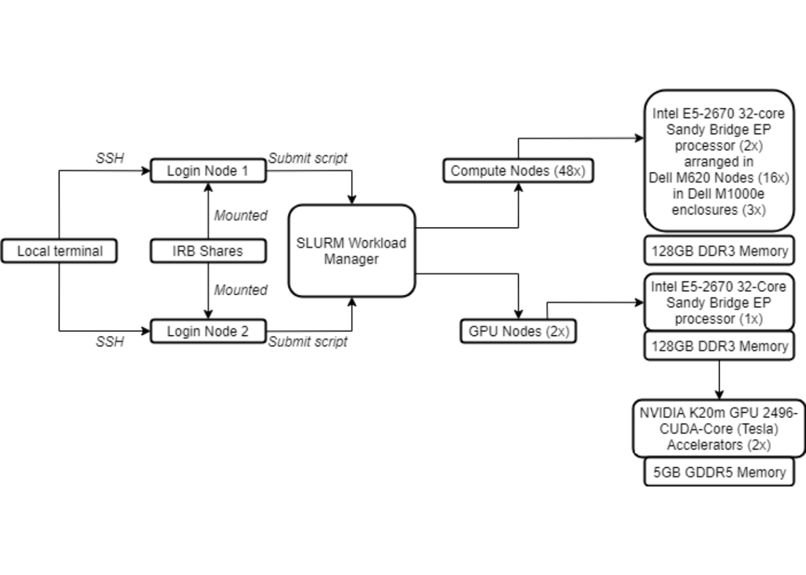

Further information about the other pieces in this diagram can be found in the following sections:

- Local terminal (**section 3.2**)
- SSH (**section 3.3**)
- Login nodes (**section 3.3.1** and **section 3.3.2**)
- SLURM (**section 4**)
- IRB share folders (**section 5.1**)
- Script submission (**section 5.2** and **section 5.3**)

# 3. Using and accessing the HPC

## 3.1 Setting up a Linux environment

- *MacOS users*: Since MacOS is actually UNIX based (the precursor to Linux) it already has the same fundamental capabilities of a Linux system. Therefore, no extra setup is necessary. Users can simply launch the terminal app to get started.
- *Windows users*: There are workarounds to allow Windows to use an SSH client. However, it is far more useful to simply install a Linux distribution. The reason for this is that many computing tools require a UNIX/Linux based environment. You can dual boot a Linux distribution by installing it as a separate operating system on your computer. This will allow you to chose between running Linux or running Windows when you start your computer.

A more convenient option is to run a Linux as a *virtual machine*. This means that Linux will essentially run as separate operating system within Windows (this makes Windows the *host*) inside a program window. You can then use both operating systems simultaneously and transfer information between them. To set this up, first install VirtualBox. VirtualBox will let you run a Linux operating system within Windows.

Go to: https://www.virtualbox.org/wiki/Downloads.

Navigate to the VirtualBox platform packages. Click on **Windows hosts**. Install Virtual Box. Once Virtual Box is installed, you need to install a Linux distribution. Linux comes in many “flavors” or variations of operating systems. For this setup, we will use the Linux operating system Ubuntu since it is ideal for beginners and is frequently updated.

To download Ubuntu, go to: https://www.ubuntu.com/download/desktop.

To set up Ubuntu within VirtualBox, use the following guide: https://linus.nci.nih.gov/bdge/installUbuntu.html.

## 3.2 The terminal

You will do most of your work through an application called the terminal. Getting used to navigating and using the terminal is extremely useful and you will need a basic familiarity with how it works to run analyses on the HPC. There are many tutorials, books, and YouTube videos available for this but I recommend the follow quick-start guide for beginners: https://medium.com/@grace.m.nolan/terminal-for-beginners-e492ba10902a.

Using the terminal in a virtual environment is a great place to get practice because it is difficult to break anything in this self-contained space. It has no access to files on the host unless you specifically set it up. If anything breaks, you can just reinstall it.

The default terminal application for most Linux distributions as well as MacOS is known as *Bash*. Bash comes with many features and its own scripting language.

## 3.3 Accessing HPC through secure shell (SSH)

The DEMON system is accessed through an SSH connection via the login nodes. SSH is a network protocol that creates a secure way to access a remote computer like the HPC cluster. Login nodes are available to those who have a `wakehealth.edu` AD account and have requested access. When off campus, a VPN must be used to access DEMON but you will still need a valid `wakehealth.edu` AD account and request access. There are two login nodes and the separate links are:

- demonln1.hpcc.wfubmc.edu
- demonln2.hpcc.wfubmc.edu

It does not matter which login node you use.

To initiate an SSH connection execute the following command to access login node 1:

```bash
localhost$ ssh wakeuserid@demonln1.hpcc.wfubmc.edu
```

Make sure to insert your Wake Forest user ID where indicated. Once you are in the login node, note that you will not have any kind of graphical user interface (GUI). Everything must be done from the terminal with text-based inputs only.

### 3.3.1 Basic setup

First, set up a `.bash_profile` file under `~` (the home directory) as explained below (replace “YOURNAME” with your user name). This profile is a set of commands stored in a text file that will run as soon as you login.

From the terminal, open the `nano` text editor and create a new file with the name “.bash_profile”. The command would be `nano .bash_profile`. A text editor will open allowing you to input the following lines of code:

```bash
# .bash_profile
# Get the aliases and functions

if[ -f ~/.bashrc];then
    . ~/.bashrc
fi

# User specific environment and startup programs

export WORK=/isilon/radiology/biosys/cluster/YOURNAME
export SCRATCH=/isilon/radiology/biosys/cluster/YOURNAME/scratch

PATH=$PATH:$HOME/bin
export PATH

alias cdw='cd /isilon/radiology/biosys/cluster/YOURNAME/'
alias cds='cd /isilon/radiology/biosys/cluster/YOURNAME/scratch'

module load slurm

# END OF .bash_profile
```

Once you are done, save by pressing `Ctrl + O`. Then press `enter` to confirm the changes you’ve made. Press `Ctrl + X` to quit.

To load the bash profile, run `source ~/.bash_profile`. This bash setup file provides the following features:

- The `cdw` command is a shortcut to your work directory
- A system environment variable `WORK` is created of your work directory
- The `cds` command is a shortcut to your scratch directory
- A system environment variable `SCRATCH` is created of your work directory
- SLURM is loaded as the default scheduler (see **section 4**)

You may add other commands if you would like. To exit your secure connection at any point run the command `exit`. You should always log off when you are done accessing the HPC cluster.

### 3.3.2 Login node features and etiquette

Many applications come pre-installed on the login node. For a complete listing, see: https://demonhn1.hpcc.wfubmc.edu/userportal/hpc-main/hpc_quick-info.htm

The basic setup comes with the following software:

- SSH terminal: putty
- Pageant: password manager
- WinSCP: GUI-based file transferring tool
- MobaXterm or XMing: X-Window server
- RealVNC or TightVNC: VNC viewer

There is limited space on the login node and so it should not be used for long-term storage of files or for memory intensive computation. This is a shared resource so most testing should be done on a local computer first. In general, you will probably only ever be on the login node when you are ready to submit your analysis to the compute nodes.

### 3.3.3 Accessing software and installing R/Matlab package management

For the most part, our lab is moving toward only using R as our analysis environment. Therefore, this section will be much more tailored toward R package installation. However, for the rarer cases where Matlab is needed, a brief overview is also provided below.

*R package management:* Installing R packages is usually fairly straightforward. For the majority of packages, which mostly contain R code, you can install packages the following way:

1. Access a login node.
2. You will want to load specific modules, which contain important libraries, that will be used in package installation. The versions of modules frequently change when the system is updated so you will need to load the latest version of the module available on the system or the module which is most compatible with your R package installation. To do this, run `module avail` from the command line to see a list of available modules.
3. For basic package installation, you will want to load the latest version of R. As of this writing, the command to load this version of the R module would be `module load r/R-3.2.1`.
4. For other packages that require C, C++, Fortran, or other code, you will often need to load other modules in addition to loading R. Most commonly, you will need to load GCC, the GNU compiler collection which contains many important libraries used in compiling and installing software. As of this writing, the latest version of GCC can be loaded with `module load gcc/8.1.0`. To check loaded modules, you can run `module list`.
5. Next, simply type `R` to run R. In this case, it will run the version of R based on the module you loaded.
6. First check that the package you want to install is not already installed on the system. Use `installed.packages()` in R to check. For a tidier list of just the package names, run `as.vector(installed.packages()[ ,"Package"])`. Note that the Kishida Lab Job Submission Interface comes with a function to allow you to quickly search for installed packages.
7. To install the package `glmnet` for example (which requires the GCC module for Fortran libraries) we would run the following from the R command line: `install.packages('glmnet', repos='http://cran.rstudio.com/')`. The installation should take less than a minute.

This should cover most package installation cases. If a package does not install correctly, read the error message closely. In most cases, it will fail because it could not find the external libraries it needs for installation. From here, you need to determine which module on the login node would contain those libraries and load the module before trying to install the package again.

**Note**: When there is a system update some packages may no longer be installed. It is advised that you check that all the installed packages are there before you proceed with any kind of analysis on the computing cluster.

*Matlab package management:* Matlab comes pre-installed with most packages and libraries you will need. For other licensed toolboxes that are not available the system or installing packages found through Matlab’s installation interface you will need to contact the system administrator because you do not have write/execution permissions for the Matlab folders. For third-party packages, you can simply put them in the same directory as your prefs file, Matlab script, and dirs files when you run analysis (**see section 5.2** and **section 5.3**).

# 4. The Simple Linux Utility for Resource Management (SLURM)

## 4.1 Introduction to SLURM

SLURM is the interface we will use to send information to and from the compute nodes. SLURM manages all incoming requests from different users who will be accessing the HPC cluster simultaneously. It has many features which allows us to specify exactly how we want to run our analyses and how much system resources we wish to allocate. Although SLURM manages and queues the incoming requests we send it, it cannot do anything about the quality of these requests. If you allocate too many system resources to your job, or let the job run too long, you will waste resources that others could be using. Therefore, make sure you know what you are doing before you submit a job.

### 4.1.1 SLURM processing workflow

Once SLURM receives a job submitted by the user from the login node, it begins to process it. This section will contain a breakdown of the pieces of this process. These terms are important because they are used when the user specifies the allocation of system resources when submitting analysis.

At the highest level we have a *job* which is submitted to SLURM by the user. Each job has one or more *job steps* involved and each of these steps may be composed of one or more *tasks* - instances of a run program - the amount of which is specified by the user. Each task uses one or more *CPU*. In other words, this system indicates the way a particular job that is submitted to the HPC cluster is able to be processed in chunks by the CPUs in each node. In general, tasks and processor cores are approximately synonymous. That is, roughly speaking, each task uses one core unless you explicitly request otherwise. A new instance of the program (for example, running the same script with a different parameter) would be a separate task, a new instance of the program, that would run on a different CPU. This approximation is useful when specifying the options for your job run.

The initiation of the job creation process is generally the `sbatch` command (see **section 4.2**). This job may be composed of a series of steps. Each step is initiated using the `srun` command for parallel jobs. Task and CPU specifications are dealt with using special commands sent to `sbatch`. This process is detailed in **section 4.2**.

### 4.1.2 Common SLURM commands

For more information about the available commands and parameters in SLURM visit the man pages located at: https://slurm.schedmd.com/man_index/html.

Or, simply type `man [command]` to get info on a specified command.

## 4.2 SLURM scripts and the `sbatch` command

### 4.2.1 Building a SLURM script

When you want to submit a job to the HPC cluster, you collect all the relevant information into one shell script file. This relevant information includes:

- All the specifications of the job run
- The output after analysis is complete
- Absolute paths to the directories containing any analysis files
- Absolute paths to the directories containing the R or Matlab script files

The Kishida Lab job submission interface will automatically handle all of the directory specifications, building of the SLURM script file, job submission, and output organization. This is detailed in **section 5**.

A basic Matlab-based SLURM script might look something like this:

```bash
#!/bin/bash
#SBATCH -J myMatlabJob             # Job Name
#SBATCH -0 path/to/myMatlabJob.o%j # Name of the output file
#SBATCH -n 32                      # Uncomment to set number of cores/tasks
#SBATCH -N 1                       # Number of nodes. Please don't change
#SBATCH --tasks-per-node 32        # Recommended 32 tasks/node
#SBATCH -p gpu                     # Subject to change
#SBATCH -t 00:30:00                # Run time (hh:mm:ss): 0.5 hours
set -x                              # Echo commands
module load matlab-2013a

# Prevent matlab-internal multithreading
export OMP_NUM_THREADS=1

# Start as many background serial jobs as there are cores available on the node:
cd /your/path/to/Matlab/code1
matlab -nodesktop -r "YourCode1;exit" &
cd -

cd /your/path/to/Matlab/code2
matlab -nodesktop -r "YourCode2;exit" &
cd -

# for completion of background tasks
wait
exit
```

This example, taken from the Wake Forest Medical HPC quick-startup guide, has the following features:

- `#/bin/bash` indicates that the Bash shell will be running the script.
- The `sbatch` commands follow which indicate all the specifications of the job run to SLURM (see **section 4.2.2**).
- `set-x` is not strictly needed but will print executed commands to the terminal.
- Matlab is loaded.
- Internal multithreading in Matlab is turned off.
- Paths to matlab scripts are specified and then these scripts are run (“code1”).
- `cd -` returns the shell to the previous directory.
- Another script is then run (“code2”).
- The `wait` command makes sure the entire script is run before the job is considered terminated.

Note that this job has just one *step* which is to run the entire script. There are no calls to `srun` which would count as additional steps within this job.

To actually run the script, you would enter the following in the command line:

```bash
module load slurm
sbatch MyMatlabJob.sh
```

The Matlab scripts generated by the Kishida Lab job submission interface are simpler and do not include all of the same options. See **section 5** for more details.

An R-based SLURM script might look something like this:

```bash
#!/bin/bash
#SBATCH -J myRJob                  # Job Name
#SBATCH -0 path/to/myMatlabJob.o%j # Name of the output file
#SBATCH -n 32                      # Uncomment to set number of cores/tasks
#SBATCH -N 1                       # Number of nodes. Please don't change
#SBATCH --tasks-per-node 32        # Recommended 32 tasks/node
#SBATCH -p gpu                     # Subject to change
#SBATCH -t 00:30:00                # Run time (hh:mm:ss): 0.5 hours
set -x                              # Echo commands
module load r/R-3.2.1

# Prevent R-internal multithreading
export OMP_NUM_THREADS=1

# Start as many background serial jobs as there are cores available on the node:
cd /your/path/to/R/code1
Rscript YourCode1
cd -

cd /your/path/to/R/code2
Rscript YourCode2
cd -


# for completion of background tasks
wait
exit
```

### 4.2.2 Important `sbatch` options

- -a, –array: Used to submit a job array. Multiple jobs will be executed with the same parameters based on array indices specified (currently not available as of this writing).
- -c, –cpus-per-task: Specifies the number of CPUs to be used per each task that was requested
- -J, job-name: Name of the job
- –mem-per-cpu: The minimum amount of memory requested for each allocated CPU
- -N, –nodes: The minimum nodes to be allocated for the job.
- -n, –ntasks: Specifies the number of tasks (processes) to run and to allocate enough resources for these tasks.
- –ntasks-per-core: Specifies the maximum number of `--ntasks` that would be run on each core. This is usually meant to be used with the `--ntasks` option.
- –ntasks-per-node, –tasks-per-node: Requests that `--ntasks` be run on each allocated node. This option is usually meant to be used with `--nodes`.
- -t, –time: A limit on the total run time of the job. This is specified in the format 00:00:00 indicating hours, minutes, and seconds.

So how do you decide what to set for these parameters? In general, optimizing all of these parameters is taken on a case-by-case basis. For most of the work in the Kishida Lab, the following general guidelines should be followed:

- If you request a high amount of resources to be allocated for your job, your job may complete quickly but it may also be sitting in the queue for a long time as it waits for other jobs run by other users to finish and free up resources.
- You can generally think of the number of tasks requested as the number of cores you want to use within your job
- When you run `--ntasks` it is indicated the numbers of tasks spread out over the nodes. If you run `--ntask=16 --nodes=1` you will run 16 tasks per node. If you run `--ntasks=16 --nodes=2` then will run 8 tasks per node (16/2).
- A good general strategy is to start on the low end and increase the allocated resources when you have a better sense of what you need.

Issues can arise when submitting many jobs at once or submitting large jobs. Slurm may become overloaded which will stop the cluster from functioning optimally. To avoid this scenario keep the following in mind:

- If you are submitting many jobs at once through a shell script, pause 0.5 to 1 second between each `sbatch` submit.
- Ensure each job takes at least 5-10 minutes to run so the scheduler can spend the right amount of time to set up, run, and break down scheduled jobs.

## 4.3 Parallel v. serial computing

There are multiple ways to process a particular job on the computing cluster. The setup for the Kishida Lab interface assumes you will be running serial jobs. It takes specific setup within a submitted script to run a a multithreaded or MPI job and these details will not be covered in this document.

*Serial Jobs (Non-parallel nodes, non-parallel CPUs):* This is the default and most basic way to run a job. SLURM will process the job on one core at a time on the first node assigned to the job. Serial jobs are unlikely to be much faster than your laptop/personal computer.

*Multithreaded Jobs on a Single Node (Non-parallel nodes, parallel CPUs):* Here a job will be distributed over multiple CPUs within a single node. However, nodes will still be run serially. To achieve this, you need code within your script that splits up the operations into chunks which are then sent to different cores. Usually, you will use a parallel processing framework called OpenMP (written in C++) to do this. In R, this sometimes entails a mixing of R and C++ code. However, certain R packages will implement this for you in the computation (for example, `glmnet`).

See also the following CRAN packages:

- BiocParallel
- future.apply
- plyr
- parallel
- foreach

The default behavior of OpenMP is to use all cores available within a node. To override this behavior or set a specific number of nodes, a SLURM environment variable should be set in the SLURM script:

```bash
OMP_NUM_THREADS=$SLURM_NTASKS
export OMP_NUM_THREADS=N
```

*MPI Jobs (Parallel nodes, parallel CPUs):* MPI (message passing interface) is a series of libraries that allow for the parallelization of jobs in high performance computing environments. OpenMPI is a popular MPI library that is highly supported on a number of different compilers. Other libraries include Intel MPI, MPICH, and LAM MPI.

To run an MPI job, it must first be configured within your script. Once this is done, then OpenMPI must be evoked within the SLURM script. For example, add the following lines to the SLURM script:

```bash
module load openmpi/gnu
module list

which mpirun
mpirun yourScript
```

For more information on running MPI jobs within R and Matlab, see **section 6.3**.

# 5. Kishida Lab job submission interface

For the most part, this is the primary way you will be likely to interact with SLURM. This interface is designed to deal with the rigid file directory requirements of IRB shares to help you organize your data, submit to SLURM, and archive after analysis is complete.

The IRB share directory is accessible by the HPC cluster and is therefore the place where all data for analysis should be stored. Currently, only $IRB00017138$ is accessible on the HPC cluster. Others may be added in the future.

The general procedure you will follow is as follows:

1. Load your data into the IRB share directory. Note that you need to put your data in a specific place for the Kishida Lab job submission interface to work. More detail on this is found in **section 5.1**.
2. Access the login node.
3. Navigate to the IRB share folder from the login node. The IRB share folder $IRB00017138$ is located at `/isilon/datalake/irb/IRB00017138/`.
4. Load the R module, any modules you will need for analysis, and start R.
5. Run the appropriate scripts in the Kishida Lab job submission interface. These scripts will set up the correct folders and submit your files to SLURM.
6. Wait for email alerts indicating your job is complete. When you receive the altert, run the function that transfers the job files into your job folder.
7. Repeat steps 5-6 (useful for staging) or run the archival function to permanently store your results in the IRB share folder.
8. Shutdown the remote connection.
9. Remove or copy your results in the IRB share to another computer for further work.

More detail for these steps will be given in **section 5.2** and **section 5.3**. Documentation for the functions in the Kishida Lab job submission interface are found in **section 6.1**.

## 5.1 Directory structure in the IRB share folder

Once you are on the login node are ready to begin analysis, navigate to the IRB share. The standardized directory structure of the IRB share folder is shown below:

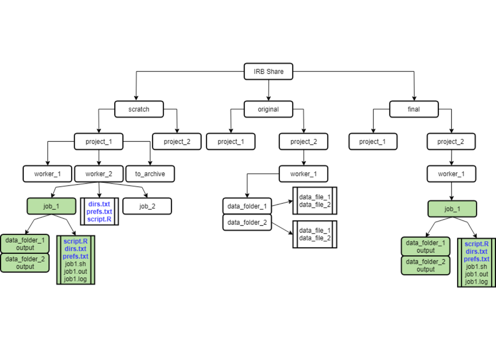

All IRB shares will contain three folders. Each of these functions has a specific function and respecting these functions should be followed during analysis. The Kishida Lab job submission interface is designed to respect these rules.

- *Original*: Raw data should be stored here. Once it is stored here, you should not remove it.
- *Scratch*: The scratch folder is a working folder for staging or temporary data storage. Do not try to permanently store anything here as it is not backed up.
- *Final*: Analyzed, final data should be stored here.

More detail on the subdirectories in these folders provided below.

### 5.1.1 Subdirectories in `/original`

Individual lab projects will be found inside the `/original` directory. For example, currently many members of the lab are working on voltammetry data. Any analysis related to this data should thus be stored in the `/VoltammetryModeling` folder. Within this folder are multiple workers, or users. Each member of the lab is responsible for creating their own folder. When you are ready for analysis, create a new subfolder in `/irbShare/original/project/worker/`. This folder will contain all the files and subdirectories that you intend to be used for analysis on the HPC cluster. You do not need to create your own folders in `/scratch` or `/final` as the job submission interace will do this for you.

### 5.1.2 Subdirectories in `/scratch`

When you run the function to set up folders (see **section 5.2**), it will generate the appropriate subfolders within `/scratch`. These include a specific worker and their associated projected. Inside each project folder is a `job` folder. This is where you will put your list of directories that you want to run the analysis over, list of preferences for SLURM, and the R or Matlab script you want to run. Each time you run a job on SLURM, the output will appear as one of the job folders when you are finished.

This folder can be used for *staging* if necessary. If you need to use the output of one run into a new run, you can keep running jobs until you get your final output. Any output you want to archive should be copied into the `/to_archive` folder. When you run the archival function, it will automatically copy this into the `/final` folder for storage.

## 5.2 Setup process

First, access the login node via a secure connection. Once you are inside, navigate to the IRB directory and load the R module. Then start R. Once R is running, run `source("path/to/kishid_lab_JSI.R")` in R. This will load all the functions into memory. You should see a few messages print out on screen indicating that the job submission interface correctly loaded. The first function you should run is `setup()` with the appropriate parameters (see **section 6.1**).

If the `workerName` does not exist, `setup()` will create the a directory for the worker based on the worker’s name, all necessary subfolders, an empty `dirs.txt` file, and a `prefs.txt` file with empty parameters. If the worker does exist already (because `setup()` was run previously) then just a new `prefs.txt` and a new `dirs.txt` file will be created.

## 5.3 Submitting a job to SLURM

### 5.3.1 File setup

In order to submit a job to SLURM, the following must be satisfied:

1. All modules (e.g. R, Matlab, gcc, SLURM) you will be using in your analysis must be preloaded before you start R and evoke the job submission interface.
2. `prefs.txt` must be filled out. You do not need to fill out everything but at a minimum you should probably have entries for `job-name` and `time`. The Kishida Lab job submission interface will not let you run a `prefs.txt` file with all of the parameters empty. For more details on how to set these parameters see **section 4.2.2**. The submission interface will use what you will out in here to generate a SLURM shell script that is submitted to SLURM. Note that you *must* keep the $=$ sign and fill out the parameters without any spaces following it.
3. `dirs.txt` must include paths formatted from the `original` directory. For example, the following would be a valid in a `dirs.txt` file:

```
/original/projectB/sanjeev/subject1
/original/projectB/sanjeev/subject2
/original/projectB/sanjeev/subject3
/original/projectB/sanjeev/subject4
/original/projectB/sanjeev/subject5
```

4. The R/Matlab script you intend to run over your data folders must be in `/scratch/projectName/workerName` - the same location as `prefs.txt` and `dirs.txt`. It must end in either `.R` or `.m`. If this is not the case, you will receive an error. The script type is specified when you run the script (see **section 5.3.2**).
5. All directories that a script is going to be run over *must* be a part of the same parent directory. In the example above, all directories of interest will be under `/original/projectB/sanjeev`. You can make any subfolders you would like under your worker name folder to accomplish this. For example, the data folders you will run the script over could be found in `/orignal/projectB/sanjeev/dopamine_optimization`.

In most cases, there are errors to make sure that all of the above requirements are fulfilled. If you make a mistake you will likely get an error.

### 5.3.2 Running scripts (normally)

To run a script, you simple run `runAnalysis()` with all of the specified parameters while in the parent IRB directory. If everything was set up correctly, a SLURM script will be created based on the preferences you specified and the script you loaded will be run over the data folders you specified. Email alerts, if you set them, will arrive when the job ends.

When the job ends, run `moveOutputFilesToJobFolders()` to transfer the output files into the job directory.

**WARNING**: Do NOT modify any files within the job directory while your job is running! Wait until after you receive notice that the job has finished and you have run `moveOutputFilesToJobFolders()`!!!

### 5.3.3 Running your own SLURM files

The job submission interface sets up all pertinent output folders and creates a SLURM script to run. If you would like to keep these features of the interface that make the folders but also make modifications to the SLURM file and/or upload your own SLURM file with custom settings, then you can use the special functions that allow you to use `runAnalysis()` in two steps.

First, run `setup()` to create the template files for `dirs.txt` and `prefs.txt` (or load your own template files). Load your R/Matlab script into this folder. Then run `prepareFilesForAnalysis()`. A job file will be created and you will find `dirs.txt`, `prefs.txt`, and your script moved into this job folder. You will also find the SLURM script here. You can modify it as you wish or replace it with your own SLURM script. **If you want to use your own SLURM script, make sure it has the same name as the job name!** When you are ready, use `submitToSlurm()` to run your script over the folders with the specified settings.

When the job ends, run `moveOutputFilesToJobFolders()` to transfer the output files into the job directory.

### 5.3.4 Archiving job data

You will generally archive an entire job folder. In other cases, you may want to perform multiple jobs, combine the output together in some way, and then save it. Whatever the case, simply collect all the data you want to archive into one folder. Place this folder in the `to_archive` folder found in `scratch/projectName/workerName/`. When you are ready, run `archive()` with the correct parameters. This will automatically move anything in this folder (including its subfolders) into the `/final` folder.

### 5.3.5 Other features

In some cases, a job will be submitted but immedietly fail. This might be because there is a problem with a node, you selected incorrect settings, or some other reason. In any case, you usually just want to change something small in your SLURM script or R/MATLAB script and then resubmit. The `resubmitJob()` function will allow you to do this. It also has a separate option if you would like to exclude a node. Sometimes a node will fail repeatedly when you are assigned to it. By sending in a list of nodes to the `exclude` parameter if the `resubmitJob()` function, you can prevent the job from being sent to a specific node.

**Note**: If you run this function and the job submits successfully, any output you happen to have in the `/scratch` job folder may be overwritten! This function is really only intended to be used in cases where the job folder is empty because the script submission was unsuccessful or the output failed in some way.

Another simple feature is the `checkPackages()` function which simplifies the output of the R function `installed.packages()`. The R function returns a whole table. `checkPackages()` simply returns a named logical vector of the queried packages and their availabity on the system.

### 5.3.6 Example of a standard run using the interface

A typical session, from start to finish would look something like this. This example assumes your the data folders of interest are already loaded into `/original`, the `kishida_lab_JSI.R` is loaded somewhere on the system, the worker folder already exists in `/scratch`, and an R script is already loaded.

```bash
# hpc-snamjoshi @ hpc-snamjoshi in ~ [11:42:41] C:255
$ ssh snamjosh@demonln1.hpcc.wfubmc.edu
snamjosh@demonln1.hpcc.wfubmc.edu\'s password:
Last login: Tue Aug 14 11:27:08 2018 from ptcrc-071qmw.medctr.ad.wfubmc.edu
WARNING WARNING WARNING WARNING WARNING WARNING WARNING WARNING WARNING

This is a Wake Forest University Baptist Medical Center (WFUBMC) interest
computer system.  All WFUBMC interest computer systems and related
equipment are intended for the communication, transmission, processing,
and storage of official or other authorized information ONLY.

USE OF THIS OR ANY OTHER WFUBMC INTEREST COMPUTER SYSTEM CONSTITUTES
CONSENT TO PERIODIC REVIEWS AT ALL TIMES.  IF YOU DO NOT AGREE TO
THESE TERMS, LOG OFF NOW !!!

[snamjosh@demonln1 ~]$ module load r/R-3.2.1
[snamjosh@demonln1 ~]$ module load gcc/8.1.0
[snamjosh@demonln1 ~]$ cd /isilon/datalake/irb/IRB00017138/
[snamjosh@demonln1 ~]$ R

R version 3.2.1 (2015-06-18) -- "World-Famous Astronaut"
Copyright (C) 2015 The R Foundation for Statistical Computing
Platform: x86_64-unknown-linux-gnu (64-bit)

R is free software and comes with ABSOLUTELY NO WARRANTY.
You are welcome to redistribute it under certain conditions.
Type 'license()' or 'licence()' for distribution details.

  Natural language support but running in an English locale

R is a collaborative project with many contributors.
Type 'contributors()' for more information and
'citation()' on how to cite R or R packages in publications.

Type 'demo()' for some demos, 'help()' for on-line help, or
'help.start()' for an HTML browser interface to help.
Type 'q()' to quit R.

> source("final/VoltammetryModeling/kishida_lab_JSI_v1.R")
====================================================================
Kishida Lab Job Submission Interface
Version: 1.0
Author: Sanjeev Namjoshi
Contact: snamjosh@wakehealth.edu
====================================================================
Please ensure the following requirements are met before proceeding:
 1. You sourced this file while in the root folder of the IRB directory.
 2. Your modules are loaded.
 3. Your data folders are in /original/project/worker/.

Instructions:
 * Use setup() to create a new worker folder and to_archive folder or to create new prefs.txt and dirs.txt files.
 * Use runAnalysis() to create a SLURM script and submit a job based on the content of your R script, dirs.txt, and prefs.txt.
 * Use archive() to archive anything in the to_archive folder.
 * Use prepareFilesForAnalysis() followed by submitToSlurm() if you wish to modify the SLURM script before submitting for analysis.
 * Use resubmitJob() to resubmit a job with the current scripts and preferences. Note that this may overwrite any data in scratch/project/worker/job.
 * Use checkPackages() to check packages that are installed on the system.
 * Use moveOutputFilesToJobFolders() to move SLURM output into /scratch.

Please submit an issue at https://github.com/snamjoshi/kishidaJSI/issues for comments, questions, or feature requests.
> setup(workerName = "sanjeev", projectName = "projectB")
Setup complete.
Please put your R/MATLAB script in scratch/project/worker before proceeding.
> runAnalysis(workerName = "sanjeev", projectName = "projectB",
  + jobName = "job1", scriptName = "script.R", scriptType = "R",
  + email = "neuro.lab.kishida@gmail.com")
Checking input files...
Ready to build SLURM scripts.
Are you sure you want to proceed? (y/n): y
[1] "y"
Creating SLURM script and building job folders...
Submitted batch job XXXXXXX
job1 submitted to SLURM queue.
Enter:
 squeue -u [your_user_name]
in the terminal to see the status of your running jobs.
```

When you receive the notification that the job has finished running, run `moveOutputFilesToJobFolders()`.

```bash
> moveOutputFilesToJobFolders("sanjeev", "projectB", "job1")
SLURM output moved to job folders in /scratch.
```

After you have finished all your jobs and you are ready to archive, move everything you want to archive to the `/to_archive` folder. Then run the following:

```bash
> archive(workerName = "sanjeev", projectName = "projectB")
Files successfully archived.
> q()
[snamjosh@demonln1 ~]$ exit
logout
Connection to demonln1.hpcc.wfubmc.edu closed.

# hpc-snamjoshi @ hpc-snamjoshi in ~ [11:45:41] C:255
$ exit
```

# 6. Appendix

## 6.1 Documentation for Kishida Lab JSI functions

**Note**: This documentation only includes the functions that the user will interact with. For more complete documentation please visit: https://github.com/snamjoshi/kishidaJSI/.

> `archive` *Archives data in the* `/final` *directory*

**Usage**: `archive(workerName, projectName)`

**Arguments**:

- `workerName [chr]`: A character vector specifying the worker name.
- `projectName [chr]`: A character vector specifying the desired project name.

> `checkPackages` *Check which packages are installed in R*

**Description**: A clean version of `installed.packages()` that returns a named logical vector indicating which of the queried packages are currently installed.

**Usage**: `checkPackages(pkg)`

**Arguments**:

- `pkg [chr]`: A character vectory of package names to query.

> `moveOutputFilesToJobFolders` *Transfers the output of SLURM to the job folder*

**Description**: SLURM outputs files into the data directories within /original/project/worker/data. This function moves them into the job folders within /scratch/project/worker/job.

**Usage**: `moveOutputFilesToJobFolders(workerName, projectName, jobName)`

**Arguments**:

- `workerName [chr]`: A character vector specifying the worker name.
- `projectName [chr]`: A character vector specifying the desired project name.
- `jobName [chr]`: A character vector specifying the job name. Must be alphanumeric.

> `prepareFilesForAnalysis` *Creates SLURM script and organizes directories*

**Description**: Checks all of the user’s input files. If everything is in the correct format and directory, it generates a SLURM script based on the `prefs.txt` and `dirs.txt` files and creates a job folder. This function creates the SLURM script but does not run it. This allows the worker to modify the SLURM script or replace it with their own. Intended to be used with `submitToSlurm()`.

**Usage**: `prepareFilesForAnalysis(workerName, projectName, jobName, scriptName, scriptType=c("R", "MATLAB"), email=NULL, mpthreads=1)`

**Arguments**:

- `workerName [chr]`: A character vector specifying the worker name.
- `projectName [chr]`: A character vector specifying the desired project name.
- `jobName [chr]`: A character vector specifying the job name. Must be alphanumeric.
- `scriptName [chr]`: A character vector specifying the script name including the file extension.
- `scriptType [chr]`: A character vector specifying either `R` or `MATLAB`. Script must end in either .R or .m.
- `email [chr]`: A character vector specifying a valid email address. Defaults to `NULL`.
- `mpthreads [int]`: An integer indicating the number of cores to be used in parallel processing. Defaults to 1.

> `resubmitJob` *Resubmits a previously submitted job*

**Description**: Resubmits a previously submitted job with the same scripts and preferences. Intended to be used if job submission fails for some reason and the SLURM script or R script needs a minor modification before resubmission. Note that using this function may overwrite anything in the job folder if a job with the same name is in `scratch/projectName/workerName`. Can optionally exclude specific nodes from running in analysis.

**Usage**: `resubmitJob(workerName, projectName, jobName, scriptName, exclude = NULL)`

**Arguments**:

- `workerName [chr]`: A character vector specifying the worker name.
- `projectName [chr]`: A character vector specifying the desired project name.
- `jobName [chr]`: A character vector specifying the job name. Must be alphanumeric.
- `scriptName [chr]`: A character vector specifying the script name including the file extension.
- `exclude [chr]`: A character vector specifying the nodes to exclude. Nodes must be of the format XXX, for example, `c(“005”, “021”, “100”) would request excluding nodes 5, 21, and 100.

> `runAnalysis` *Runs a script over directories on the HPCC*

**Description**: Checks all of the user’s input files. If everything is in the correct format and directory, it generates a SLURM script based on the `prefs.txt` and `dirs.txt` files and creates a job folder. The SLURM script is then run with `sbatch`. This function is a wrapper around `prepareFilesForAnalysis()` and `submitToSlurm()`.

**Usage**: `runAnalysis(workerName, projectName, jobName, scriptName, scriptType=c("R", "MATLAB"), email=NULL, mpthreads=1)`

**Arguments**:

- `workerName [chr]`: A character vector specifying the worker name.
- `projectName [chr]`: A character vector specifying the desired project name.
- `jobName [chr]`: A character vector specifying the job name. Must be alphanumeric.
- `scriptName [chr]`: A character vector specifying the script name including the file extension.
- `scriptType [chr]`: A character vector specifying either `R` or `MATLAB`. Script must end in either .R or .m
- `email [chr]`: A character vector specifying a valid email address. Defaults to `NULL`.
- `mpthreads [int]`: An integer indicating the number of cores to be used in parallel processing. Defaults to 1.

> `setup` *Setup file structure and template files for worker*

**Description**: If the worker does not exist it creates setup folders within `/scratch` and template files `prefs.txt` and `dirs.txt` in `/scratch/projectNane/workerName`. If the worker does exist it just creates the template files.

**Usage**: `setup(workerName, projectName)`

**Arguments**:

- `workerName [chr]`: A character vector specifying the worker name.
- `projectName [chr]`: A character vector specifying the desired project name.

> `submitToSlurm` *Submits a SLURM script to* `sbatch`

**Description**: Moves all files into the job directory and submits the SLURM script to `sbatch`.

**Usage**: `submitToSlurm(workername, projectName, jobName, scriptName)`

**Arguments**:

- `workerName [chr]`: A character vector specifying the worker name.
- `projectName [chr]`: A character vector specifying the desired project name.
- `jobName [chr]`: A character vector specifying the job name. Must be alphanumeric.
- `scriptName [chr]`: A character vector specifying the script name including the file extension.

## 6.2 Contact information

For any issues with the Kishida lab job submission interface or errors/typos in this document, please submit an issue at https://github.com/snamjoshi/kishidaJSI/issues.

For any other issues regarding the HPC environment, contact the system administrator, Mike Greer, at: `msgreer(at)wakehealth(dot)edu`.

## 6.3 Extra resources

*OpenMP (MPI) overview*: https://computing.llnl.gov/tutorials/openMP/#Introduction

*OpenMP tutorial*: https://computing.llnl.gov/tutorials/openMP/exercise.html

*Intro to parallel computing*: https://computing.llnl.gov/tutorials/parallel_comp/#Overview

*Message Passing Interface (MPI)*: https://computing.llnl.gov/tutorials/mpi/

*SLURM Training*:

- https://slurm.schedmd.com/tutorials.html
- https://www.open-mpi.org/video/?category=slurm

*SLURM and Moab*: https://computing.llnl.gov/tutorials/moab/

*Advanced MPI*: https://hpc.llnl.gov/sites/default/files/DavidCronkSlides.pdf

*Open MP*: https://computing.llnl.gov/tutorials/openMP/#ProgrammingModel

*Other useful resources*:

- https://www.xsede.org/web/xup/online-training
- http://archer.ac.uk/training/virtual/
- https://software-carpentry.org/lessons/
- https://www.youtube.com/watch?v=CLtbXfwSNCI&list=PLGj2a3KTwhRZR9yvRG2f3F7svgYYs2GSa